# M4_W2_L1_Lattice_Plotting_System

Alexander Cormack

18 November 2022

# The Lattice Plotting System

The lattice plotting system is implemented using the following packages:

- *lattice*: contains code for producing Trellis graphics, which are independent of the “base” graphics system; includes function like **xyplot**, **bwplot**, **levelplot**
- *grid*: implements a different graphing system independent of the “base” system; the *lattice* package builds on top of *grid*
  - we seldom call functions from the *grid* pacakage directly

The lattice plotting system does not have a “two-phase” aspect with separate plotting and annotation like in base plotting

All plotting/annotation is done at once with a single function call

## Lattice functions

- **xyplot**: this is the main function for creating scatterplots
- **bwplot**: box-and-whiskers plots (boxplots)
- **histogram**: histograms
- **stripplot**: like a boxplot but with actual points
- **dotplot**: plot dots on “violin strings”
- **splom**: scatterplot matrix; like **pairs** in base plotting system
- **levelplot, contourplot**: for plotting “image” data

Lattice functions generally take a formula for their first argument, usally of the form:

xyplot(y ~ x | f * g, data)

- we use the *formula notation* here, hence the tilde.
- on the left of the tilde is the y-axis variable, on the right is the x-axis variable
- f and g are *conditioning variables* - they are optional
  - the asterisk indicates an interaction between two variables
- the second argument is the data frame or list from which the variables in the formula should be looked up
  - if no data frame or list is passed, then the parent frame is used
- if no other arguments are passed, there are defaults that can be used

## Simple lattice plot

```r
library(lattice)
library(datasets)
xyplot(Ozone ~ Wind, data = airquality)
```

[output not shown]

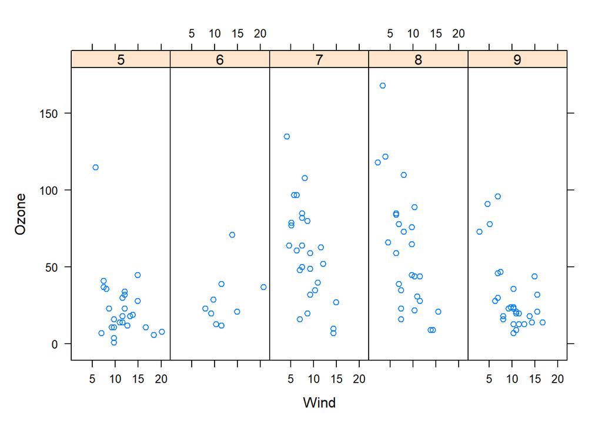

```r
library(lattice)
library(datasets)
## Convert 'Month' to a factor variable
airquality <- transform(airquality, Month = factor(Month))
xyplot(Ozone ~ Wind | Month, data = airquality, layout = c(5, 1))
```

## Lattice behaviour

Lattice functions behave differently from base graphics functions in one critical way. Base graphics functions plot data directly to the graphics device (screen, PDF file, etc.) whereas lattice graph functions return an object of class **trellis**.

The print methods for lattice funcctions actually do the work of plotting the data on the graphics device.

Lattice functions return “plot objects” that can, in principle, be stored (but it’s usually better to just save the code + data).

On the command line, trellis objects are *auto-printed* so that it appears the function is plotting the data.

```r
p <- xyplot(Ozone ~ Wind, data = airquality) ## Nothing happens!
```

```r
print(p) ## Plot appears
```

[output not shown]

```r
xyplot(Ozone ~ Wind, data = airquality) ## Auto-printing
```

[output not shown]

## Lattice panel functions

Lattice functions have a **panel function** which controls what happens inside each panel of the plot.

The *lattice* package comes with default panel functions, but you can supply your own if you want to customize what happens in each panel.

Panel functions receive the x/y coordinates of the data points in their panel (along with any optional arguments).

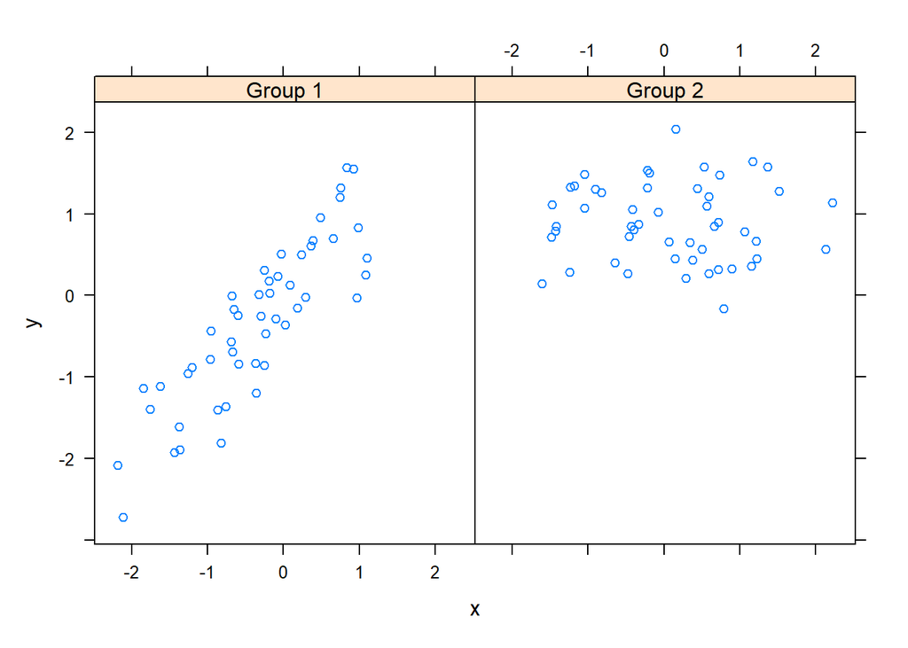

```r
set.seed(10)
x <- rnorm(100)
f <- rep(0:1, each = 50)
y <- x + f - f * x + rnorm(100, sd = 0.5)
f <- factor(f, labels = c("Group 1", "Group 2"))
xyplot(y ~ x | f, layout = c(2, 1))  ## Plot with 2 panels
```

Here we create a custom panel showing the median y:

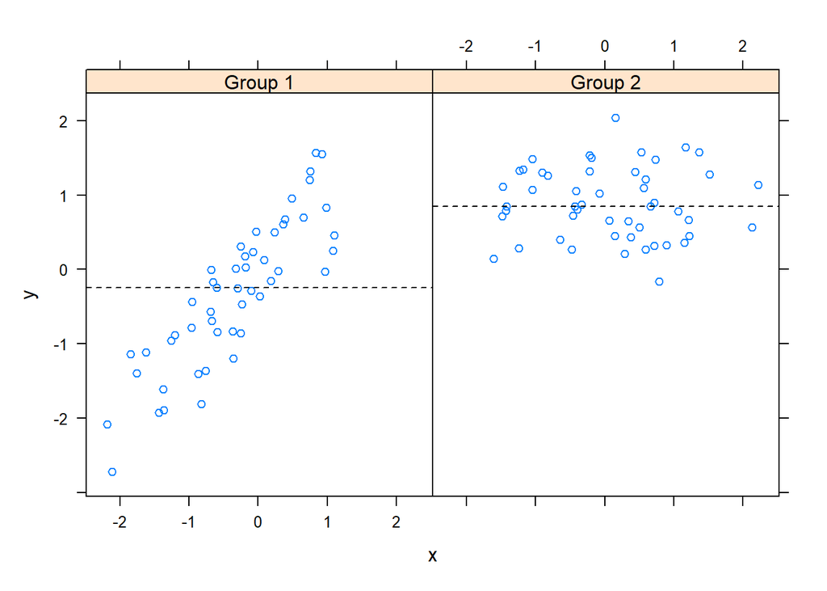

```r
## Custom panel argument
xyplot(y ~ x | f, panel = function(x, y, ...) {
        panel.xyplot(x, y, ...)  ## First call the default pane function for 'xyplot'
        panel.abline(h = median(y), lty = 2)  ## Add a horizontal line at the median
})
```

Here we create a custome panel with a regression line:

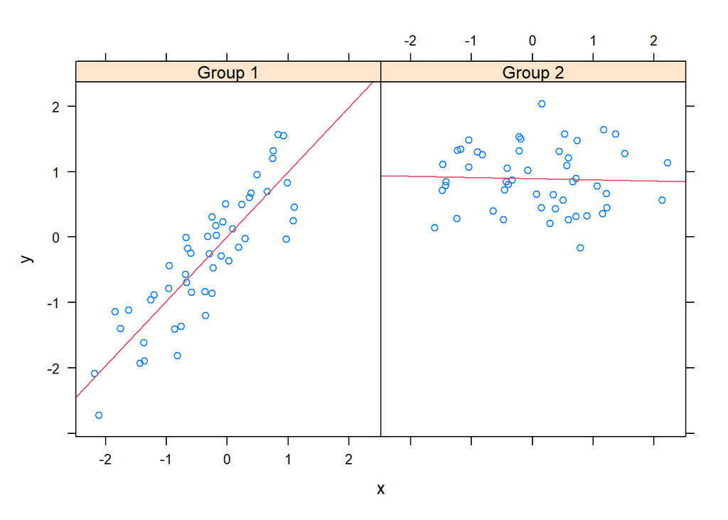

```r
## Custom panel function
xyplot(y ~ x | f, panel = function(x, y, ...) {
        panel.xyplot(x, y, ...)  ## First call the default panel function
        panel.lmline(x, y, col = 2)  ## Overlay a simple linear regression line
})
```

## Many panel lattice plot: example from MAACS

Study: Mouse Allergen and Asthma Cohort Study (MAACS)

Study subjects: children with asthma living in Baltimore City, many allergic to mouse allergen

Design: observational study, baseline home visit + every 3 months for a year

Question: how does indoor airborne mouse allergen vary over time and across subjects?

Ahluwalia et al., *Journal of Allergy and Clinical Immunology*, 2013

Lattice plots was used to easily and quickly generate 150 panels, one for each of the patients and their five data points.

## Summary

Lattice plots are constructed with a single function call to a core lattice function (e.g. xyplot)

Aspects like margins and spacing are automatically handled and defaults are usually sufficient

The lattice system is ideal for creating conditioning plots where you examine the same kind of plot under many different conditions

Panel functions can be specificed/customised to modify what is plotted in each of the plot panels